# Final Project: Crime Prediction Model

# 4. HAND OFF

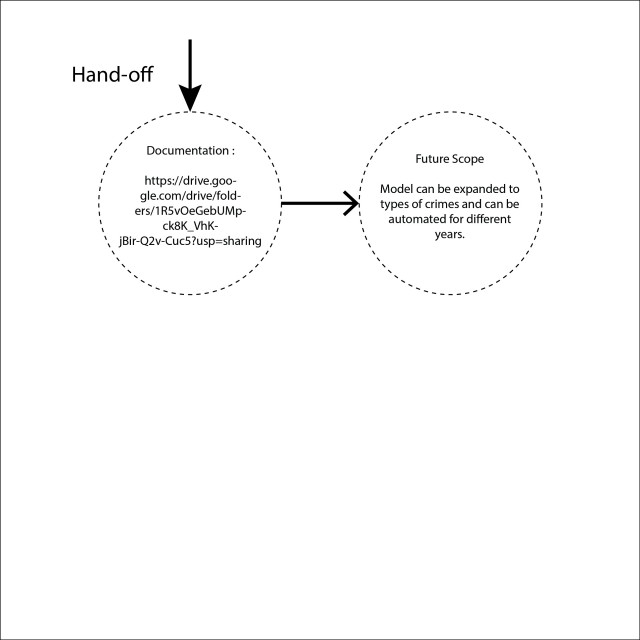

## 4.1.Conclusions

From the analysis, there is a clear indication that the crime numbers within a census tract are dependent on population, persons per acre, African-American popultion, Hispanic populations, Unemployment rates and education levels. Although crimes are currently decreasing in NYC, the model indicates that the predicted values are more than the current values due to variations in the demographic data. Hence, it is important for “Mayor’s office of Criminal Justice” to invest the same or more in their policing services in the city.

Some of the other general recommendations include : policy makers should make strategies to make sure that racial clustering or segregation does not happen within census tracts. The vacant units can be minimised by changing its rent/cost of the unit upon the occupany. Non-populated census tracts have to invest in amenities, public places and entertainment buildings to attract population so that it get distributed as well.

## 4.2.Limitations

These analysis was done on only some demographic variables. Crime can be dependent on various other factors and for more accuracy, more variable should be incorporated into this model. The analysis could have been done for more years than just 2010 for better evaluation of the models.

## 4.3.Future Work/ Building upon the model

1. Currently, the model is only for predicting number of crimes. This can be expanded to number of different types of crimes.
2. This model can be automated for every 10 years to estimate crime numbers with changes in census tract boundaries. This will give estimates of crime numbers which can be used for distribution of resources and city planning.

## 4.4 Sources

Brownlee, J. (2016, August 16). A Gentle Introduction to XGBoost for Applied Machine Learning. Retrieved May 7, 2019, from Machine Learning Mastery website: https://machinelearningmastery.com/gentle-introduction-xgboost-applied-machine-learning/

Francis, D. (2017). What Reduced Crime in New York City. Retrieved May 7, 2019, from https://www.nber.org/digest/jan03/w9061.html

NYC - Mayor’s Office of Criminal Justice - We advise the Mayor on solutions to the City’s public safety problems by looking at the criminal justice system as a whole - and beyond. (n.d.). Retrieved May 7, 2019, from https://criminaljustice.cityofnewyork.us/

### Code + Data + Files

https://drive.google.com/drive/folders/1R5vOeGebUMpck8K_VhKjBir-Q2v-Cuc5?usp=sharing